# TITLE by YOUR_NAME_HERE

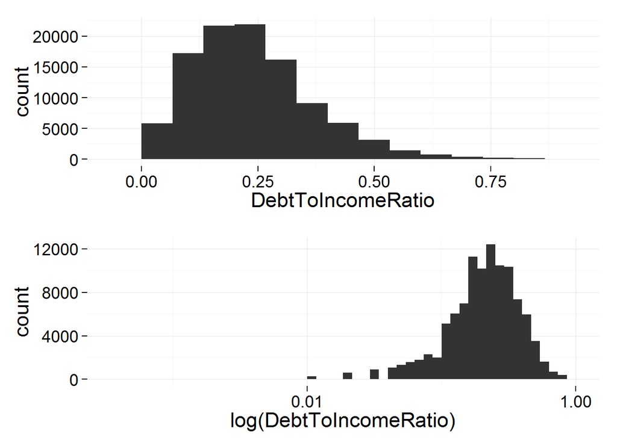

```r
#set theme
theme_set(theme_minimal(17))

#filtered data, excluding the DI greater than 99% of the collection
filtered_ds <- subset(loan_ds,!is.na(DebtToIncomeRatio))
exclude <- quantile(filtered_ds$DebtToIncomeRatio, 0.99)

#histogram of DI and the same histogram with the levels of DI log-transformed
p1 <- ggplot(aes(x = DebtToIncomeRatio),
       data = subset(filtered_ds, DebtToIncomeRatio<exclude)) +
  geom_histogram(binwidth = 1/15)

p2 <- p1 +
  scale_x_log10() +
  xlab("log(DebtToIncomeRatio)")

#plot p1 and p2 into a unique figure
grid.arrange(p1, p2, ncol=1)
```

Most of people have less than 30% of their income committed to debts.

```
##    Min. 1st Qu.  Median    Mean 3rd Qu.    Max.
##  0.0000  0.1340  0.1840  0.1928  0.2500  0.4975
```

```
## stat_bin: binwidth defaulted to range/30. Use 'binwidth = x' to adjust this.
```

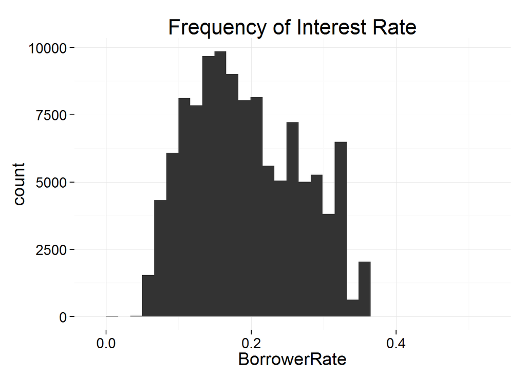

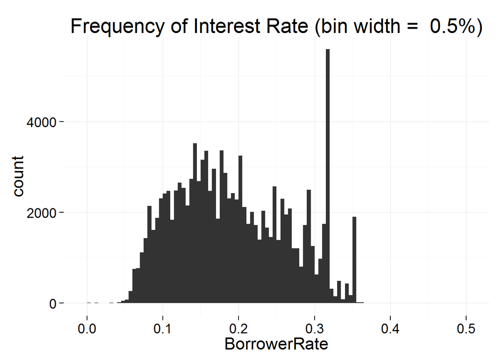

# Univariate Analysis

### What is the structure of your dataset?

### What is/are the main feature(s) of interest in your dataset?

Features of interest in the lending/loan data set Term: The length of the loan expressed in months; LoanStatus: The current status of the loan, as Cancelled, Defaulted, etc; ClosedDate: Closed date, when applicable; BorrowerRate: The Borrower’s interest rate for the loan; ProsperRating (numeric): The Risk Rating assigned at the time the listing was created. Varies from 0 (worst) to 7 (best); ListingCategory: The category of the listing that the borrower selected when posting their listing; IsBorrowerHomeowner: If the Borrower is classified as a homeowner by the Prosper Criteria; DebtToIncomeRatio: The debt to income ratio of the borrower at the time the credit profile was pulle. This value is capped at 10.01; StatedMonthlyIncome: The monthly income the borrower stated at the time the listing was created; LoanOriginalAmount: The origination amount of the loan; LoanOriginationDate: The date the loan was originated.

### What other features in the dataset do you think will help support your investigation into your feature(s) of interest?

### Did you create any new variables from existing variables in the dataset?

### Of the features you investigated, were there any unusual distributions? Did you perform any operations on the data to tidy, adjust, or change the form of the data? If so, why did you do this?

# Bivariate Plots Section

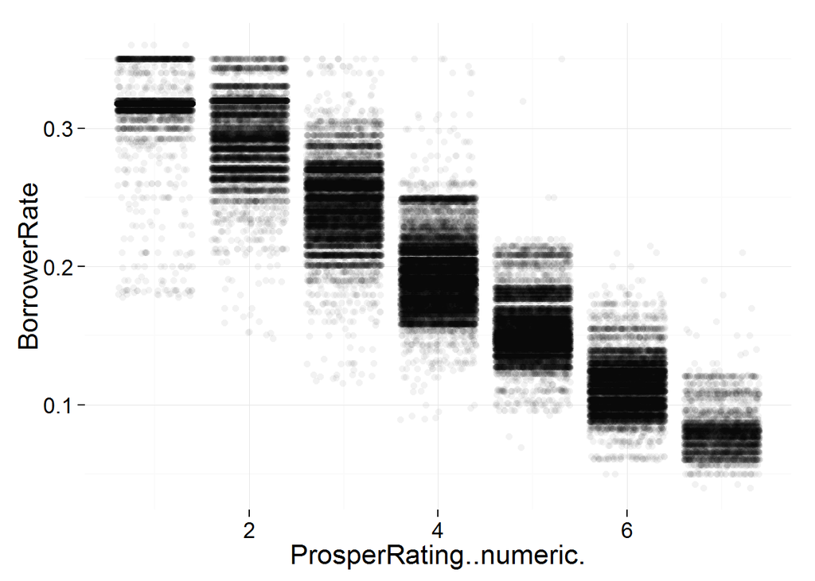

Interest Rate of Home owners

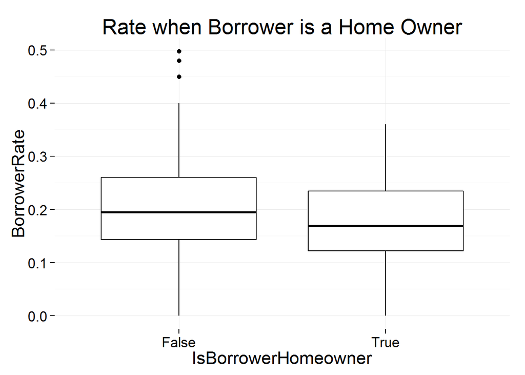

Mean Monthly payment of Defaulted/Charged off loans grouped by state

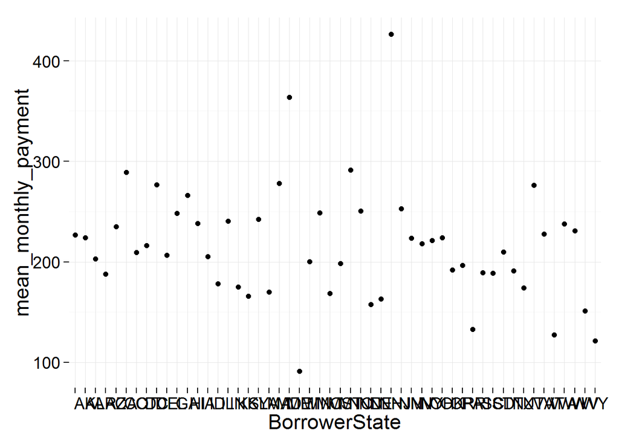

```
##  BorrowerState mean_monthly_payment mean_borrower_rate       n
##         : 1    Min.   : 91.27       Min.   :0.1425     Min.   :  3.0
##  AK     : 1    1st Qu.:185.51       1st Qu.:0.2065     1st Qu.: 17.5
##  AL     : 1    Median :213.17       Median :0.2157     Median : 47.5
##  AR     : 1    Mean   :216.00       Mean   :0.2192     Mean   : 96.5
##  AZ     : 1    3rd Qu.:240.92       3rd Qu.:0.2358     3rd Qu.:102.0
##  CA     : 1    Max.   :426.58       Max.   :0.2779     Max.   :732.0
##  (Other):46
```

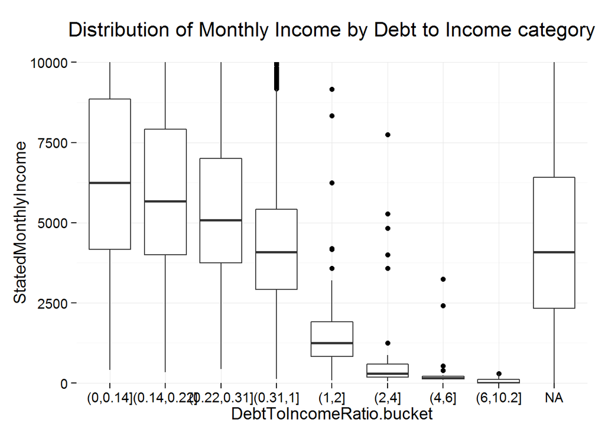

Debts and Interest Rate

# Bivariate Analysis

The more one is in debt, the more expensive is to take more loans.

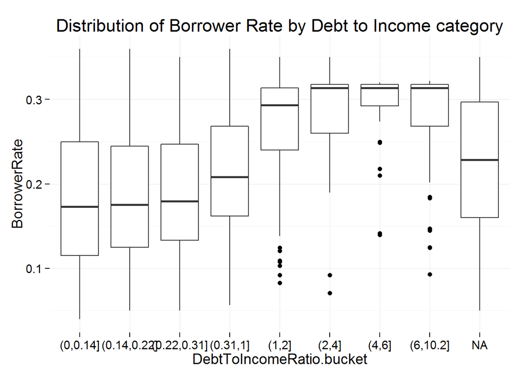

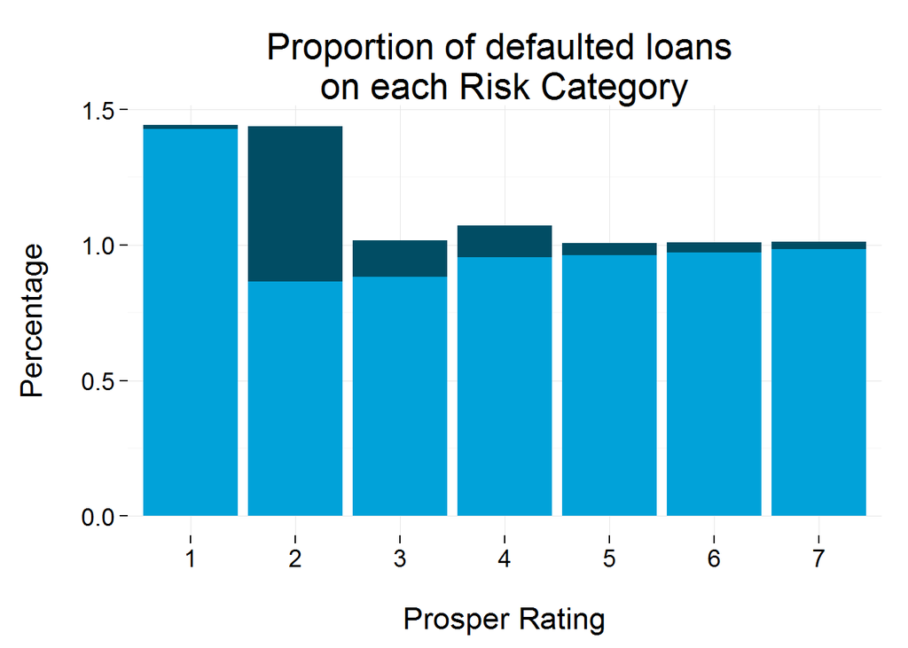

### What was the strongest relationship you found?

Debt to Income Ration is closely related to loan issuance. Bad risk score directly impact the loan issuance decision

# Multivariate Plots Section

Interest Rate, Term and Debt Ratio

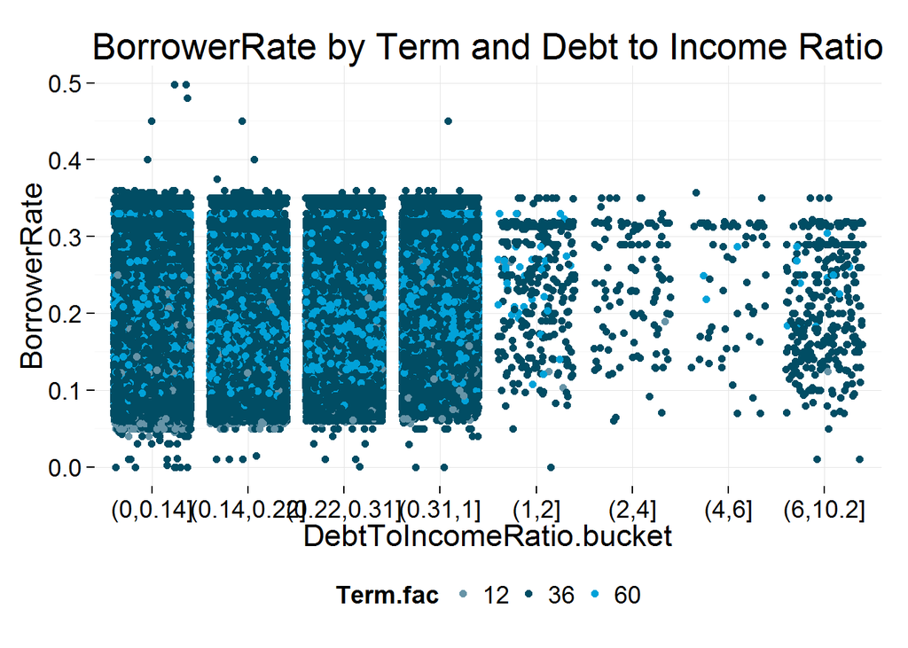

Percentages of D/I ratio Buckets by Term

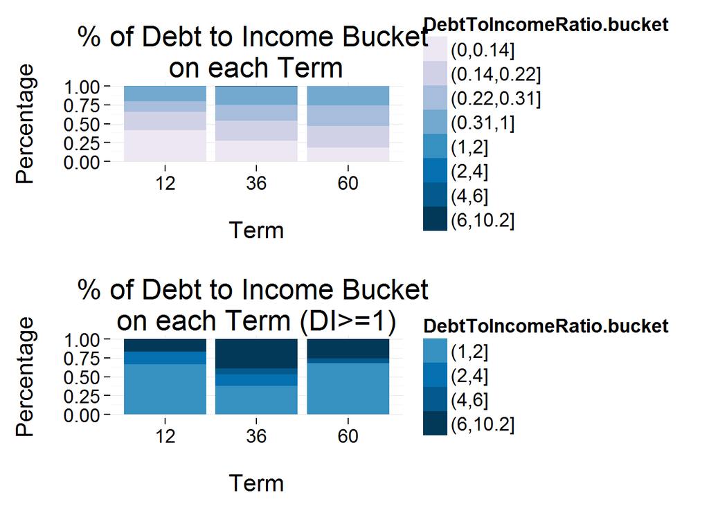

Interest Rates with different Terms Changed Over Years

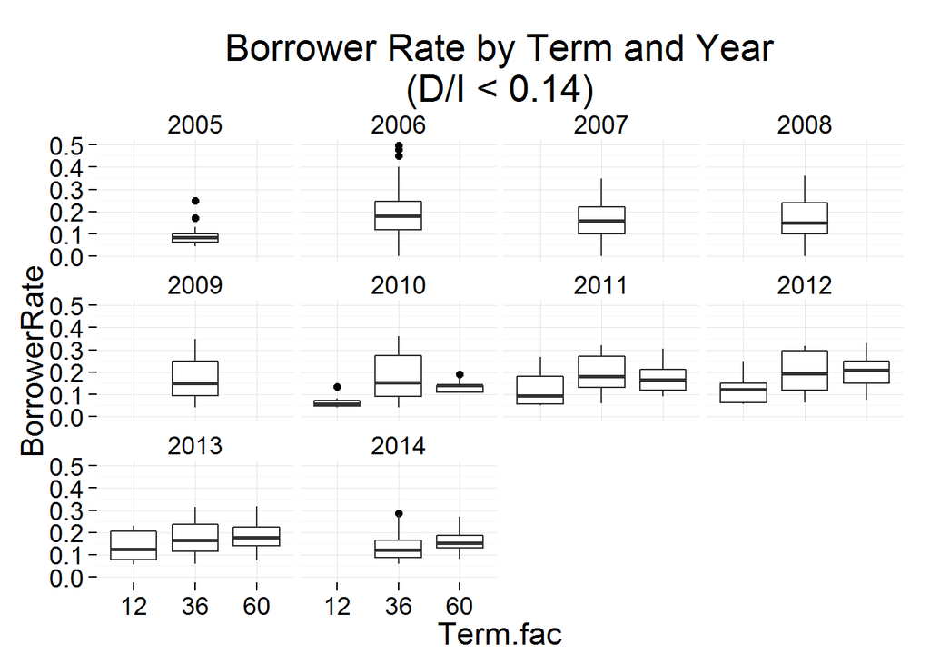

# Multivariate Analysis

worst debt to Income Ratios are more common in loans with terms of 36 months. ### Talk about some of the relationships you observed in this part of the investigation. Were there features that strengthened each other in terms of looking at your feature(s) of interest?

### Were there any interesting or surprising interactions between features?

### OPTIONAL: Did you create any models with your dataset? Discuss the strengths and limitations of your model.

# Final Plots and Summary

### Plot One

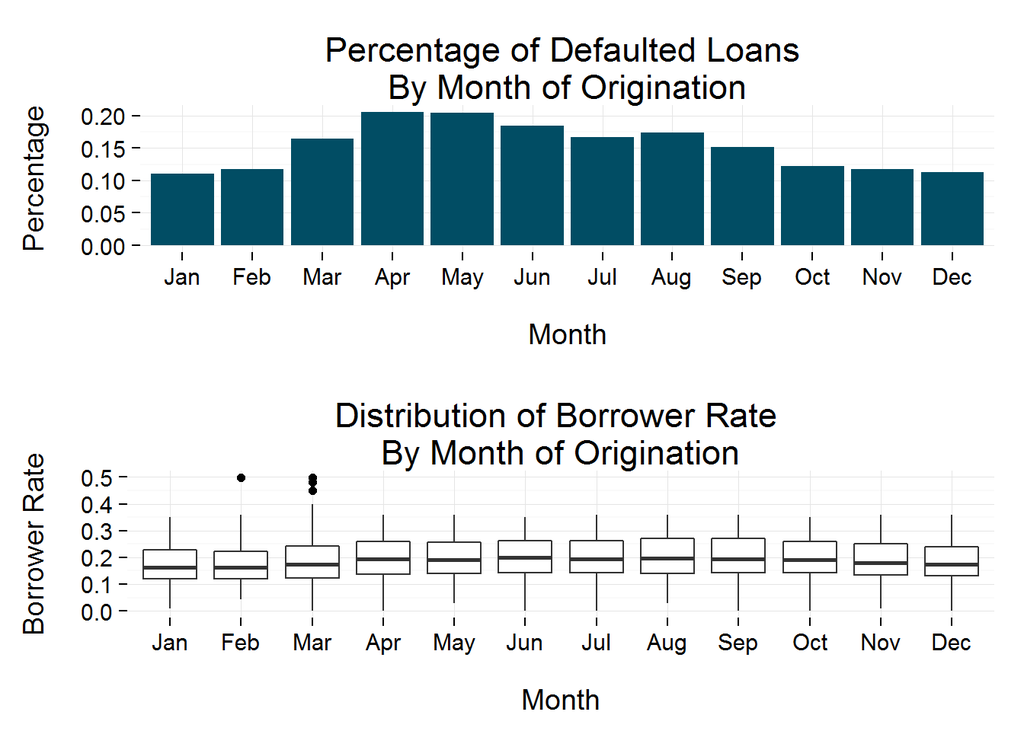

### Description One

In other words, ss the percentage of defaulted loans increases, the average borrower rate also increases. With this chart, I suppose that both variable were linked somewhat and this insight drove to my last analyzes on this data set.

### Plot Two

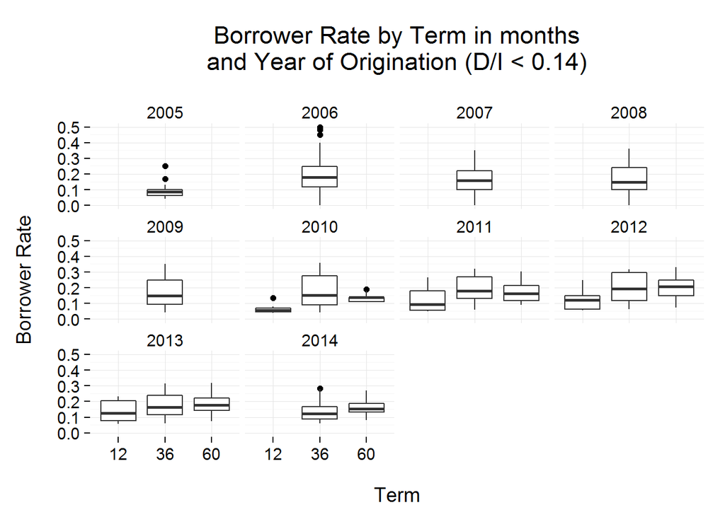

### Description Two

Also, the figure above shows that the loans with 12 and 60 months have begun to be made in 2010, with the average borrower rate much smaller than loans with 36 month. As pointed before, in 2011, the loans with the two Terms have already begun to be more dispersed, although the distance between the second and the third quartile always was more wide in the loans with Terms of 36 months.

I would say that the borrower rate of loans with term of 60 month has became really greater than the 36 months in 2014, when even the second quartile of the 60 months almost became greater than the third quartile of loans with term of 36 months.

This chart helped me understand how the dynamic of the borrowers rates changed through the years. Initially I had observed that loans with 36 month had been more dispersed than the 60 month and I assumed that it was a characteristic of the loans. After this chart, I wondered if there were another reason for the dispersion.

### Plot Three

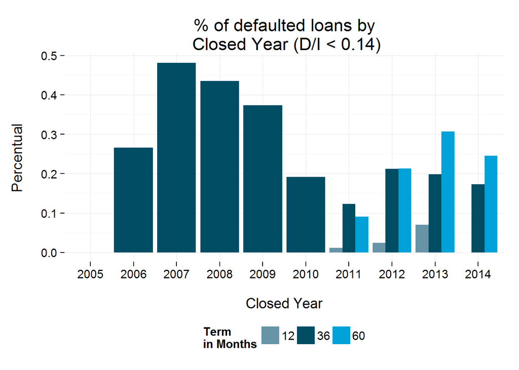

### Description Three

In the chart above, I decided to use the year when the loans were closed because I had imagined that years when were verified a increase in defaulted ratio, the borrower rates probably would also increase.

## I choose this last figure because this relation between defaulted ratio and borrower rate helped me to understand why the borrower rate changed his behaviour throughout the years between different terms.

# Reflection

Initially, the big data set and the number of features created lot of confusion around what to pick and what not pick as a variable. But once started to poke around the data, trying to find something interesting to explore, without success. Then, I decided to make some assumptions and try to check them in the collection. After that, my project took off.

After pursuing too many libraries putting them all to work at once initially was very difficult . But slowly got used to it.During my analysis, I verified that many variables that I have believed that would have a greater effect on Borrowers rate, actually presented just a smaller role. Maybe if I tried to build a model to predict the borrower rate, all these variables would be useful, but not alone, just together.

At the end, I just found two variable that helped me to understand the borrower rate variations. Debt to Income Ratio and the overall Defaulted ratio. The last one was curious. It seems be connected to the level of all interest rates for a particular year.

I also did not find any good reason to transform any variable. I have expected to find something, given that the data set is related to money.